# HW6 Linear mixed-effect models

## 0. Packages and data

```r
library(tidyverse)
library(lme4)
library(lmerTest)
library(lingtypology) # only for linguistic mapping
library(broom)
```

### UPSID database

```r
upsid <- read_csv("https://raw.githubusercontent.com/LingData2019/LingData2020/master/data/upsid.csv")
upsid
```

| language | area | consonants | vowels |
| --- | --- | --- | --- |
| Afade | Africa | 27 | 9 |
| Achumawi | North America | 17 | 6 |
| Adzera | Papua | 18 | 7 |
| Eastern Arrernte | Australia | 27 | 3 |
| Amele | Papua | 15 | 5 |
| Angaataha | Papua | 12 | 9 |
| Aghem | Africa | 25 | 10 |
| Aproumu Aizi | Africa | 24 | 9 |
| Ahtena | North America | 30 | 5 |
| Hokkaido Ainu | Eurasia | 11 | 5 |

[output cut: 441 more lines]

```r
# you can map the languages using the lingtypology package
# map.feature(upsid$language,
#            features = upsid$area,
#            label = upsid$language,
#            label.hide = TRUE)
```

In this work, you will fit a number of linear and linear mixed-effect models that predict the number of vowels in a language by the number of consonants and other variables.

## 1. Linear model

### 1.1

Make a scatterplot of the number of consonants and the number of vowels using the `ggplot()`.

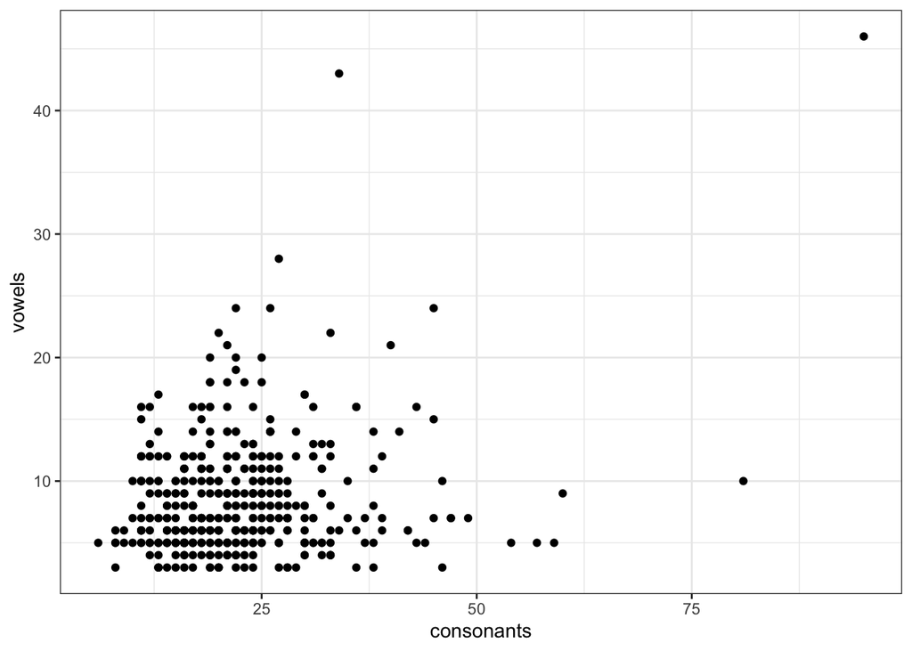

```r
# we use the theme_bw() theme, you can use other themes if you want
```

### 1.2

Fit the basic linear model `fit1` that predicts the number of vowels by the number of consonants. Look at the summary of the model.

```
##
## Call:
## lm(formula = vowels ~ consonants, data = upsid)
##
## Residuals:
##    Min     1Q Median     3Q    Max
## -8.148 -2.897 -1.208  2.441 33.203
##
## Coefficients:
##             Estimate Std. Error t value Pr(>|t|)
## (Intercept)  5.96920    0.56512  10.563  < 2e-16 ***
## consonants   0.11259    0.02317   4.859 1.63e-06 ***
## ---
## Signif. codes:  0 '***' 0.001 '**' 0.01 '*' 0.05 '.' 0.1 ' ' 1
##
## Residual standard error: 4.67 on 449 degrees of freedom
## Multiple R-squared:  0.04996,    Adjusted R-squared:  0.04785
## F-statistic: 23.61 on 1 and 449 DF,  p-value: 1.63e-06
```

### 1.3

Is `consonants` a significant predictor? Write down YES or NO.

```
YES
```

### 1.4

*no evaluation*  
To draw predictions on the graph, we may use `fortify` function. It adds column entitled `.fitted` (note period) that is calculated as a prediction of a model as well as some other columns.

Try this code and see the result:

```r
head(fortify(fit1))
```

|  | vowels | consonants | .hat | .sigma | .cooksd | .fitted | .resid | .stdresid |
| --- | --- | --- | --- | --- | --- | --- | --- | --- |
| 1 | 9 | 27 | 0.002722938 | 4.675111 | 5.283118e-09 | 9.009174 | -0.009174129 | -0.001967203 |
| 2 | 6 | 17 | 0.002953279 | 4.674262 | 2.415722e-04 | 7.883257 | -1.883256653 | -0.403872234 |
| 3 | 7 | 18 | 0.002708692 | 4.674874 | 6.192365e-05 | 7.995848 | -0.995848401 | -0.213537648 |
| 4 | 3 | 27 | 0.002722938 | 4.666459 | 2.266680e-03 | 9.009174 | -6.009174129 | -1.288543592 |
| 5 | 5 | 15 | 0.003590156 | 4.673418 | 5.857681e-04 | 7.658073 | -2.658073158 | -0.570217008 |
| 6 | 9 | 12 | 0.004914727 | 4.674434 | 3.210686e-04 | 7.320298 | 1.679702085 | 0.360573955 |

Another option is to use `augment` function from `broom` library that works in a similar way.

```r
library(broom)
head(augment(fit1))
```

| vowels | consonants | .fitted | .se.fit | .resid | .hat | .sigma | .cooksd | .std.resid |
| --- | --- | --- | --- | --- | --- | --- | --- | --- |
| 9 | 27 | 9.009174 | 0.2436838 | -0.009174129 | 0.002722938 | 4.675111 | 5.283118e-09 | -0.001967203 |
| 6 | 17 | 7.883257 | 0.2537815 | -1.883256653 | 0.002953279 | 4.674262 | 2.415722e-04 | -0.403872234 |
| 7 | 18 | 7.995848 | 0.2430455 | -0.995848401 | 0.002708692 | 4.674874 | 6.192365e-05 | -0.213537648 |
| 3 | 27 | 9.009174 | 0.2436838 | -6.009174129 | 0.002722938 | 4.666459 | 2.266680e-03 | -1.288543592 |
| 5 | 15 | 7.658073 | 0.2798108 | -2.658073158 | 0.003590156 | 4.673418 | 5.857681e-04 | -0.570217008 |
| 9 | 12 | 7.320298 | 0.3273840 | 1.679702085 | 0.004914727 | 4.674434 | 3.210686e-04 | 0.360573955 |

### 1.5

Use one of these function to add a line to the scatterplot 1.1. You have to use `geom_line` and pass the result of `augment` or `fortify` as argument `data` in `geom_line`. (E.g. `geom_line(data = <result of augment>, ...`))

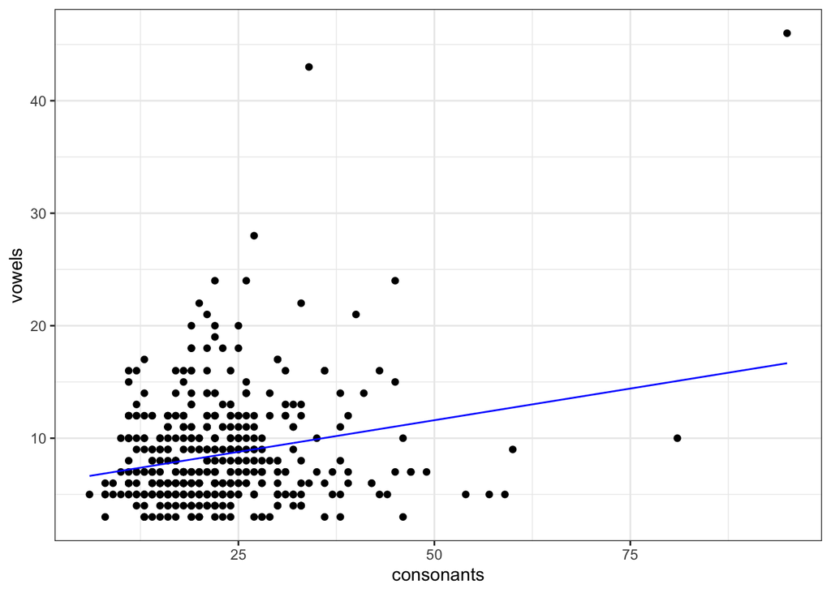

## 2. Mixed-effect models

Let us look at the data with respect to the `area` groups.

### 2.1

Re-build the scatterplot `1.1` coloring the points by `area`.

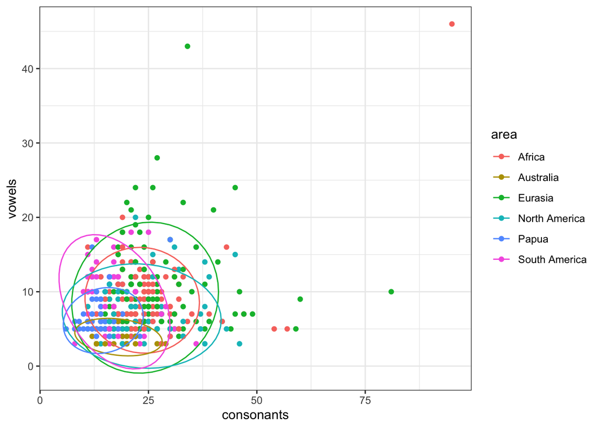

### 2.2

Use lmer() to fit the model `fit2` with random `area` group intercept. Your model is given by equation:

$$vowels = \beta_0 + \beta_1 \times consonants + u(area).$$

### 2.3

Add the regression lines to the scatterplot `2.1` using `fortify` or `augment` methods.

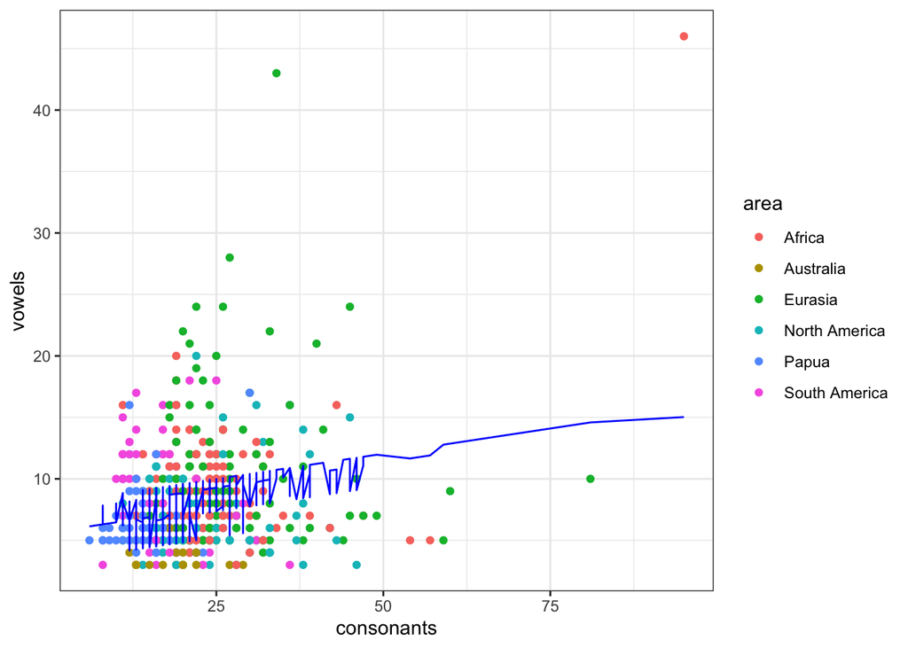

### 2.4

Interpret the results of the model. (Use `summary()` to get information about your model.) Is *consonansts* variable still significant? How it changes after we added *area* random effect? What can you say about lines on the graph? How are they located with respect to each other? Why?

```
## Linear mixed model fit by REML. t-tests use Satterthwaite's method [
## lmerModLmerTest]
## Formula: vowels ~ consonants + (1 | area)
##    Data: upsid
##
## REML criterion at convergence: 2649.4
##
## Scaled residuals:
##     Min      1Q  Median      3Q     Max
## -1.7378 -0.6176 -0.2127  0.4484  7.2066
##
## Random effects:
##  Groups   Name        Variance Std.Dev.
##  area     (Intercept)  3.336   1.826
##  Residual             20.053   4.478
## Number of obs: 451, groups:  area, 6
##
## Fixed effects:
##              Estimate Std. Error        df t value Pr(>|t|)
## (Intercept)   6.07766    0.94134   9.15205   6.456 0.000109 ***
## consonants    0.08212    0.02458 446.67797   3.341 0.000905 ***
## ---
## Signif. codes:  0 '***' 0.001 '**' 0.01 '*' 0.05 '.' 0.1 ' ' 1
##
## Correlation of Fixed Effects:
##            (Intr)
## consonants -0.556
```

## 3. Mixed-effect models with random slopes.

### 3.1

Fit the model `fit3` with random slope that depends on *area*. Your model is given by formula:

$$vowels = \beta_0 + (\beta_1 + u(area))\times consonants.$$
You can consult [this](http://bbolker.github.io/mixedmodels-misc/glmmFAQ.html#model-specification) manual to choose the correct syntax in your `lmer` formula.

### 3.2

Draw a figure with prediction lines:

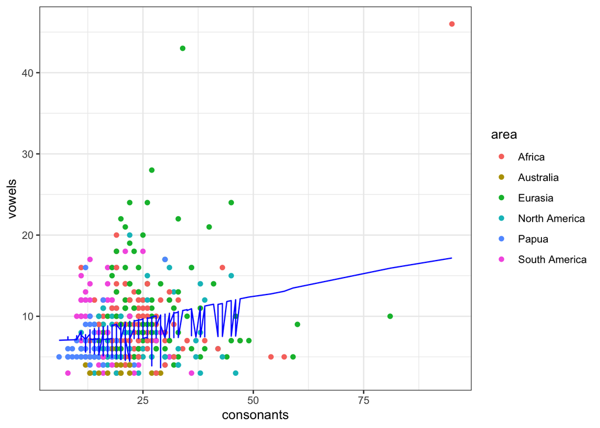

### 3.3

Interpret the results. Is *constants* still significant? Why? What can you say about lines on the graph? How are they located with respect to each other? Why?

```
## Linear mixed model fit by REML. t-tests use Satterthwaite's method [
## lmerModLmerTest]
## Formula: vowels ~ consonants + (0 + consonants | area)
##    Data: upsid
##
## REML criterion at convergence: 2650.9
##
## Scaled residuals:
##     Min      1Q  Median      3Q     Max
## -1.8910 -0.5705 -0.2539  0.4255  7.2020
##
## Random effects:
##  Groups   Name       Variance  Std.Dev.
##  area     consonants  0.007731 0.08793
##  Residual            20.106719 4.48405
## Number of obs: 451, groups:  area, 6
##
## Fixed effects:
##              Estimate Std. Error        df t value Pr(>|t|)
## (Intercept)   6.93418    0.61286 437.37643  11.314   <2e-16 ***
## consonants    0.03417    0.04630   8.68189   0.738     0.48
## ---
## Signif. codes:  0 '***' 0.001 '**' 0.01 '*' 0.05 '.' 0.1 ' ' 1
##
## Correlation of Fixed Effects:
##            (Intr)
## consonants -0.578
```

The *constants* variable is no longer significant, because its p-value now equals 0.48 >> 0.05. The lines on the graph are similar to the lines on the previous graph, but now they do not necessarily have the same slope, and some of them have different lengths as well.

## 4. Mixed-effect models with random intercept and random slopes.

Now let us assume we have both random intercept and random slope (and they are not correlated). Our model is of the form:

$$vowels = \beta_0 + u_1(area) + (\beta_1 + u_2(area))\times consonants.$$

### 4.1

Fit the model `fit4`.

### 4.2

Draw a figure with predictions:

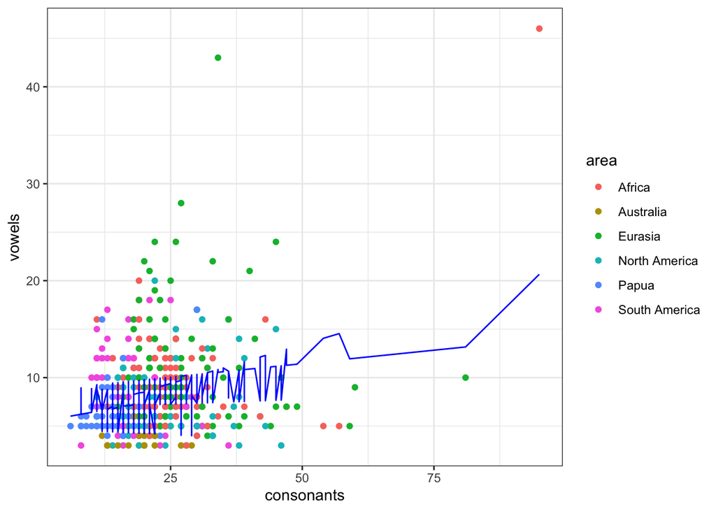

### 4.3

Interpret the results. Is *constants* significant? How can we interpret the difference between the prediction lines of these three models?

```
## Linear mixed model fit by REML. t-tests use Satterthwaite's method [
## lmerModLmerTest]
## Formula: vowels ~ consonants + (0 + consonants | area) + (1 | area)
##    Data: upsid
##
## REML criterion at convergence: 2643.3
##
## Scaled residuals:
##     Min      1Q  Median      3Q     Max
## -2.1630 -0.6011 -0.2275  0.4219  7.3599
##
## Random effects:
##  Groups   Name        Variance  Std.Dev.
##  area     consonants   0.008716 0.09336
##  area.1   (Intercept)  4.735699 2.17617
##  Residual             19.441478 4.40925
## Number of obs: 451, groups:  area, 6
##
## Fixed effects:
##             Estimate Std. Error      df t value Pr(>|t|)
## (Intercept)  6.70370    1.10137 5.13860   6.087  0.00157 **
## consonants   0.04515    0.04942 4.20173   0.914  0.41030
## ---
## Signif. codes:  0 '***' 0.001 '**' 0.01 '*' 0.05 '.' 0.1 ' ' 1
##
## Correlation of Fixed Effects:
##            (Intr)
## consonants -0.347
```

The *constants* variable is still insignificant, although its p-value has decreased a little. In this last model, each group of languages by area has its own slope and its own intercept.